# Week 3 Skill Builders

One more stab at this. We don’t use the standard errors of the models, but rather the standard error of their difference. Just like each WAIC value, each difference in WAIC values also has a standard error.

```r
set.seed(91)
waic_m4 <- WAIC( m4 , pointwise=TRUE )$WAIC
waic_m5 <- WAIC( m5 , pointwise=TRUE )$WAIC
n <- length(waic_m4)
diff_m4_m5 <- waic_m4 - waic_m5
sqrt( n*var( diff_m4_m5 ) )
```

```
## [1] 0.7487036
```

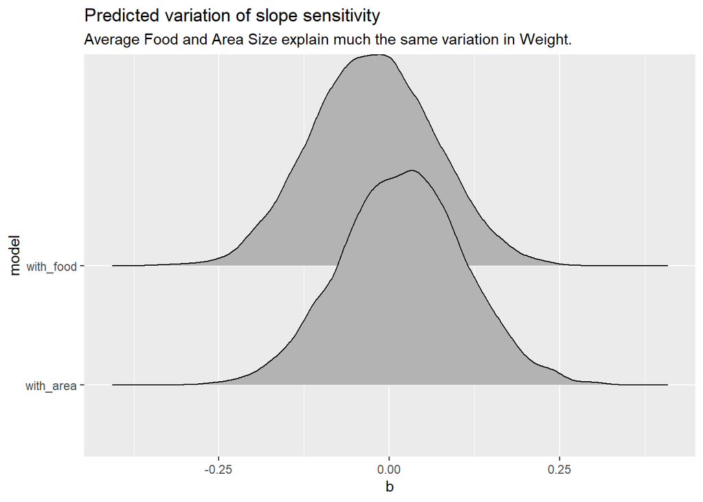

```r
library(ggridges)

with_food <- extract.samples( m4 )$b #[ ,1 ]//
with_area <- extract.samples( m5 )$b #[ ,2 ]

plot_extract <- tibble( sim =1:10000, with_food, with_area ) %>%
  pivot_longer( -sim, names_to = "model", values_to = "b")
plot_extract %>%
  ggplot( aes( b, model) ) +
    geom_density_ridges() +
    scale_fill_viridis_d() +
    theme(legend.position = "bottom") +
    labs(title = "Predicted variation of slope sensitivity",
         subtitle = "Average Food and Area Size explain much the same variation in Weight.")
```

Now look at the compare table again. We notice that:

- What do we notice?

If we imagine the 99% (corresponding to a z-score of about 2.6) interval of the difference, it’ll be about:

```r
quantile(diff_m4_m5, 0.005)
```

```
##       0.5%
## -0.2321093
```

```r
quantile(diff_m4_m5, 0.995)
```

```
##     99.5%
## 0.2056938
```

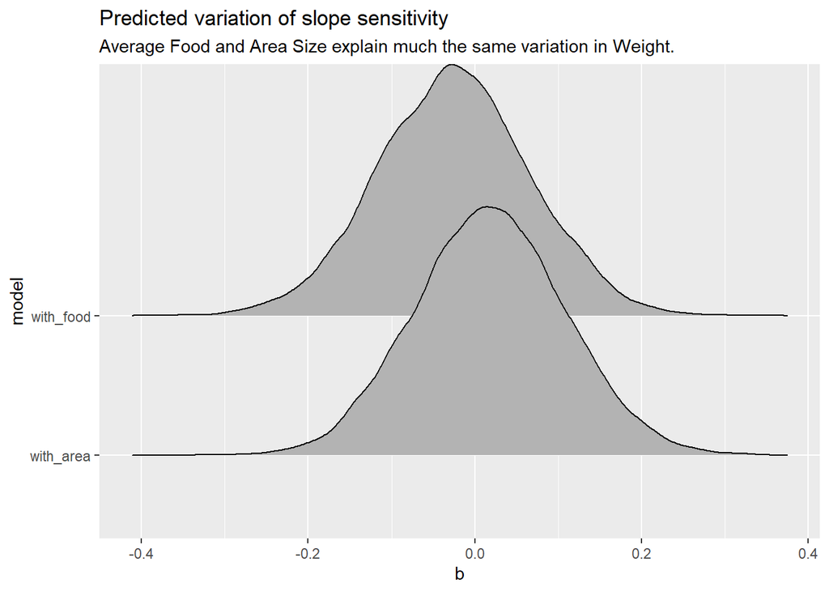

```r
library(ggridges)

with_food <- extract.samples( m4 )$b #[ ,1 ]//
with_area <- extract.samples( m5 )$b #[ ,2 ]

plot_extract <- tibble( sim =1:10000, with_food, with_area ) %>%
  pivot_longer( -sim, names_to = "model", values_to = "b")
plot_extract %>%
  ggplot( aes( b, model) ) +
    geom_density_ridges() +
    scale_fill_viridis_d() +
    theme(legend.position = "bottom") +
    labs(title = "Predicted variation of slope sensitivity",
         subtitle = "Average Food and Area Size explain much the same variation in Weight.")
```

What does all of this mean?

- Causation?
- Mediating effects?

## WAIC

*WAIC* stands for ____ ____ ? Yes it an information criterion and dutifully computes a statistic that tests the ability of a model to predict. Log odds ratios are involved, as well as the number of parameters, and thus the complexity of a model. This criterion approximates the out-of-sample deviance that converges to the cross-validation approximation in a large sample. The CV approximation, especially using the $N$-fold *leave-one-out (LOO)* strategy results in the *Pareto-smoothed* blah, blah.

WAIC is just the *log-posterior-predictive density* (lppd, that is, the Bayesian deviance) and a penalty proportional to the variance in posterior predictions:

$$WAIC(y, \Theta) = −2(lppd − \underbrace{\Sigma_i var_{\theta}\,log \,\,p(y_i|\theta))}_{penalty}$$

The $lppd$ comes from the notion of model divergence as the additional uncertainty induced by using probabilities from one distribution to describe another distribution. This divergence is often measured by the Kullback-Leibler divergence, KL divergence. The divergence is the distance in log odds ratios between two models. Our two models are everything except the one observation left out, and everything left in. Lots of computing will make our day now.

The Bayesian version of the log-probability score is called the log-pointwise-predictive-density. For some data $y$ and posterior distribution $\theta$.

$$lppd(y, \Theta) = \Sigma_i \, log \frac{1}{S} \Sigma_s p(y_i | \Theta_s)$$
where $S$ is the number of samples and is the $s$-th set of sampled parameter values in the posterior distribution.

Let’s use the `cars` dataset loaded with base R. Everyone uses this to build certain models and compare the results.

```r
data(cars)
summary(cars)
```

```
##      speed           dist
##  Min.   : 4.0   Min.   :  2.00
##  1st Qu.:12.0   1st Qu.: 26.00
##  Median :15.0   Median : 36.00
##  Mean   :15.4   Mean   : 42.98
##  3rd Qu.:19.0   3rd Qu.: 56.00
##  Max.   :25.0   Max.   :120.00
```

```r
m <- quap(
alist(
  dist ~ dnorm(mu,sigma),
  mu <- a + b*speed,
  a ~ dnorm(0,100),
  b ~ dnorm(0,10),
  sigma ~ dexp(1)
) , data=cars )
precis( m )
```

```
##             mean        sd       5.5%     94.5%
## a     -17.435078 5.8670814 -26.811807 -8.058348
## b       3.923524 0.3607517   3.346973  4.500075
## sigma  13.381957 1.1301735  11.575721 15.188192
```

```r
set.seed(42)
post <- extract.samples(m,n=1000)
```

Compare this with the OLS regression.

```r
m_OLS <- lm(cars$dist ~ 1 + cars$speed, data = cars)
summary(m_OLS)
```

```
##
## Call:
## lm(formula = cars$dist ~ 1 + cars$speed, data = cars)
##
## Residuals:
##     Min      1Q  Median      3Q     Max
## -29.069  -9.525  -2.272   9.215  43.201
##
## Coefficients:
##             Estimate Std. Error t value Pr(>|t|)
## (Intercept) -17.5791     6.7584  -2.601   0.0123 *
## cars$speed    3.9324     0.4155   9.464 1.49e-12 ***
## ---
## Signif. codes:  0 '***' 0.001 '**' 0.01 '*' 0.05 '.' 0.1 ' ' 1
##
## Residual standard error: 15.38 on 48 degrees of freedom
## Multiple R-squared:  0.6511, Adjusted R-squared:  0.6438
## F-statistic: 89.57 on 1 and 48 DF,  p-value: 1.49e-12
```

Right on the nose! They agree, almost; and, phew! The F-statistic helps us reject the null hypothesis that the intercept *and* slope are zero at a stargazingly high degree of plausibility. Ahh, but this routine does not at all help us identify those observations which might more influence our over-fitting issues.

What out our `quap` model? First, we compute the log-likelihood of each observation $i$ at each sample $s$ from the posterior:

```r
n_samples <- 1000
log_prob <- sapply( 1:n_samples ,
function(s) {
  mu <- post$a[s] + post$b[s]*cars$speed
  dnorm( cars$dist , mu , post$sigma[s] , log=TRUE )
} )
str(log_prob)
```

```
##  num [1:50, 1:1000] -3.7 -3.76 -3.91 -3.8 -3.7 ...
```

The `str()` view shows a 1000 samples column matrix with observations in each row, among other things, all scores.

We compute $lppd$, the Bayesian deviance, by averaging the samples in each row, taking the log, and adding all of the logs together (the sum of logs are like the products of probabilities, all logical *both-and*s. We have to use the function log_sum_exp to compute the log of a sum of exponentiated terms, else we might be as precise as we need to be, let alone experience under and overflow arithmetical headaches. After all of that we subtract the log of the number of samples, and thus the log of the average.

```r
n_obs <- nrow(cars)
lppd <- sapply( 1:n_obs , function(i) log_sum_exp(log_prob[i,]) - log(n_samples) )
sum(lppd)
```

```
## [1] -206.8948
```

We will need `sum(lppd)` for the total `lppd` in the WAIC formula. The penalty term p_{WAIC} adds up the variance across samples for each and every observation.

```r
pWAIC <- sapply( 1:n_obs , function(i) var(log_prob[i,]) )
sum(pWAIC)
```

```
## [1] 4.755416
```

```r
summary(pWAIC)
```

```
##     Min.  1st Qu.   Median     Mean  3rd Qu.     Max.
## 0.006917 0.010684 0.022530 0.095108 0.062112 1.566305
```

Again sum(pWAIC) returns total p_{WAIC} in the formula. At last we compute WAIC like this.

```r
 -2*( sum(lppd) - sum(pWAIC) )
```

```
## [1] 423.3005
```

You can compute the standard error of WAIC through the square root of number of cases multiplied by the variance over the individual observation terms in WAIC.

```r
waic_vec <- -2*( lppd - pWAIC )
sqrt( n_obs*var(waic_vec) )
```

```
## [1] 17.7812
```

Since each observation has a penalty in the $p_{WAIC}$ vector, we attempt to identify those observations than contribute to overfitting using the `pointwise=TRUE` feature in the `rethinking::WAIC()` function.

```r
WAIC(m, pointwise = TRUE)
```

```
##         WAIC      lppd     penalty  std_err
## 1   7.237635 -3.598478 0.020339502 17.70233
## 2   8.048130 -3.923686 0.100379606 17.70233
## 3   7.311086 -3.633240 0.022302881 17.70233
## 4   7.991447 -3.931953 0.063770991 17.70233
## 5   7.112182 -3.546686 0.009405469 17.70233
## 6   7.436658 -3.695462 0.022867284 17.70233
## 7   7.147443 -3.563198 0.010523958 17.70233
## 8   7.173855 -3.576423 0.010504541 17.70233
## 9   7.962687 -3.942900 0.038443349 17.70233
## 10  7.498280 -3.730303 0.018837226 17.70233
## 11  7.090939 -3.537321 0.008148742 17.70233
## 12  8.482876 -4.196184 0.045254287 17.70233
## 13  7.589605 -3.776389 0.018413519 17.70233
## 14  7.234496 -3.606372 0.010876508 17.70233
```

[output cut: 36 more lines]

```r
tail(cars)
```

```
##    speed dist
## 45    23   54
## 46    24   70
## 47    24   92
## 48    24   93
## 49    24  120
## 50    25   85
```

[^1]: Now for something seemingly completely different, but very much isomorphically aligned with this example, the [GE software module](https://clinicalview.gehealthcare.com/quick-guide/entropy-monitoring-valuable-tool-guiding-delivery-anesthesia) to track the degree of irregular brain function during the delivery of anaesthesia.